# Emplacamento Caminhões - Forecast

Pedro Borges

01/12/2024

# **1. PROJETO**

### **Desafío Técnico para Cientista de Dados Pleno- MT2 Data**

> Este documento foi confeccionado em `RMarkdown` através da `linguagem R` de programação, para melhor visualização e acompanhamento das análises.

### OBJETIVOS -

> 1. Desenvolver algoritmos em R para previsão de uma série histórica de emplacamento de caminhões da ANFAVEA, utilizando variáveis macroeconômicas como preditores.
> 2. Criar um aplicativo interativo em Python/Streamlit para visualização dos resultados e simulações “What If” de variáveis macroeconômicas.

## **1.1 Explicando os Dados**

### **1.1.1 - ANFAVEA**

> A Associação Nacional dos Fabricantes de Veículos Automotores, é a entidade que representa as principais empresas do setor automobilístico no Brasil. Fundada em 1956, a organização atua como porta-voz da indústria junto ao governo e à sociedade, defendendo os interesses de seus associados, que incluem fabricantes de automóveis, comerciais leves, caminhões e ônibus, além de máquinas agrícolas e de construção. Ela desempenha um papel crucial na coleta e divulgação de dados sobre a produção, venda e exportação de veículos, além de promover debates e estudos sobre temas relevantes para o desenvolvimento do setor, como novas tecnologias, segurança veicular e políticas públicas.

> As informações de séries de emplacamentos de Caminhões utilizadas para a realização desta análise foram retiradas o site da [ANFAVEA](https://anfavea.com.br/site/edicoes-em-excel/) Licenciamento Total Licenciamento Nacionais Licenciamento Importados Produção Exportação

### **1.1.2 - Variáveis Macroeconomicas**

> As seguintes variáveis macroeconômicas foram todas obtidas através da plataforma do IPEA Data disponível em: [site](http://www.ipeadata.gov.br). As variáveis e suas respectivas descrições são:

### I. Taxa de câmbio - R$ / US$ - comercial - compra - média (BM12_ERC12)

> - **Frequência:** Mensal de 1953.01 até 2024.11;
> - **Fonte:** Banco Central do Brasil, Boletim, Seção Balanço de Pagamentos (Bacen / Boletim / BP);
> - **Unidade**: R$;
> - Taxa de câmbio é o preço de uma moeda estrangeira medido em unidades ou frações (centavos) da moeda nacional. Neste caso a moeda estrangeira é o dólar. Câmbio Comercial ou Livre corresponde à média das taxas efetivas de operações no mercado interbancário, ponderada pelo volume de transações de venda do dia. Taxa calculada para transações de compra.As taxas médias são calculadas para compra, utilizando-se as cotações diárias do período em referênciaElaboração Bacen: média no período, a partir das séries de taxas diárias. Elaboração Ipeadata: conversão de moeda para Real (R$) no período entre 1953.01 e 1994.05.Nota: As transações fechadas em taxas que mais se distanciam da média do mercado (outliers) e aquelas que evidenciam formação artificial de preço ou contrárias às práticas regulares do mercado são excluídas dos cálculos.Mais informações: SGS- Sistema de Gerenciamento de Séries Temporais, Banco Central.

### II. Produto Interno Bruto (PIB) (BM12_PIB12)

> - **Frequência:** Mensal de 1990.01 até 2024.10;
> - **Fonte:** Banco Central do Brasil, Boletim, Seção Atividade Econômica (Bacen / Boletim / Ativ. Ec.);
> - **Unidade**: R$ (milhões) - Valor Nominal;
> - O Produto Interno Bruto (PIB) denominado como PIB mensal é um indicador com frequência mensal produzido pelo Banco Central do Brasil (BCB) para utilização no cálculo da relação entre agregados econômicos mensais (como dívida pública, saldo em transações correntes e saldo de crédito) e o PIB.Elaboração Bacen: estimativa é feita via interpolação dos valores trimestrais já divulgados ou dos projetados, não se tratatando de cálculo do PIB a partir de informações primárias. Nota: Este cálculo mensal é feito uma vez que o PIB calculado oficialmente no Brasil pelo IBGE, é divulgado com frequência trimestral, ao passo que várias informações econômicas compiladas pelo Banco Central são mensais. Mais informações: SGS- Sistema de Gerenciamento de Séries Temporais, Banco Central.

### III. Índice geral de preços do mercado (IGP-M) (IGP12_IGPMG12)

> - **Frequência:** Mensal de 1989.07 até 2024.10
> - **Fonte:** Fundação Getulio Vargas, Conjuntura Econômica - IGP (FGV/Conj. Econ. - IGP);
> - **Unidade**: (% a.m.);
> - O Índice Geral de Preços (IGP) registra o ritmo evolutivo de preços como medida síntese da inflação nacional. Apresenta-se em três versões: Índice Geral de Preços - 10 (IGP-10), Índice Geral de Preços do Mercado (IGP-M) e Índice Geral de Preços – Disponibilidade Interna (IGP-DI). A diferença entre eles está no período de apuração das informações para cálculo do índice. O Índice Geral de Preços do Mercado (IGP-M) é um indicador do movimento de preços que cobre todo o processo produtivo, desde preços de matérias-primas agrícolas e industriais, passando pelos preços de produtos intermediários até os de bens e serviços finais. É composto pela média ponderada do Índice de Preços ao Produtor Amplo do Mercado (IPA-M) (60%), do Índice de Preços ao Consumidor do Mercado (IPC-M) (30%) e do Índice Nacional de Custo da Construção do Mercado (INCC-M) (10%). Para efeito de coleta de preços, o IGP-M mede a evolução de preços no período compreendido entre os dias 21 do mês anterior e o dia 20 do mês de referência. Nota: Na época de transição para o Real (R$) - Julho e Agosto de 1994 - a FGV calculou o IGP-2, uma variante do IGP-M mas calculado com valores na nova moeda. O IGP-M reflete a comparação dos preços praticados na nova moeda (R$) com os preços praticados ainda em CR$ convertidos para Reais pela paridade R$ = 2750 CR$. O IGP-2 reflete a comparação dos preços praticados em R$ com os preços praticados ainda em CR$ porém convertidos para Reais pela cotação diária da URV. As 2 formas apresentam resultados distintos.

### VI. Taxa de juros - Over / Selic - acumulada no mês (BM12_TJOVER12)

> - **Frequência:** Mensal de 1974.01 até 2024.11
> - **Fonte:** Banco Central do Brasil, Boletim, Seção mercado financeiro e de capitais (Bacen/Boletim/M. Finan.);
> - **Unidade**: (% a.m.);
> - Receber uma quantia hoje ou no futuro não são evidentemente a mesma coisa. Em princípio, uma unidade monetária hoje é preferível à mesma unidade monetária disponível amanhã. Postergar uma entrada de caixa (recebimento) por certo tempo envolve um sacrifício, o qual deve ser pago mediante uma recompensa, definida pelos juros. A taxa de juro é o coeficiente que determina o valor do juro, isto é, a remuneração do fator capital utilizado durante certo período de tempoTaxa de juros acumulada mensal tendo como base a taxa Selic diária.A taxa Selic é a taxa de juros média apurada no Sistema Especial de Liquidação e Custódia (Selic), que incide sobre operações de financiamento por um dia útil (overnight), lastreadas por títulos públicos registrados no Sistema. É utilizada como instrumento primário de política monetária do Comitê de Política Monetária (Copom), visando ao cumprimento da meta para inflação. O Copom estabelece a meta para a taxa Selic, e cabe à mesa de operações do mercado aberto do Banco Central do Brasil (BCB) manter a taxa Selic diária próxima à meta.

### V. Produção industrial - fabricação de veículos automotores, reboques e carrocerias: índice de quantum (média 2022 = 100) (PIMPFN12_QIIGNN2012)

> - **Frequência:** Mensal de 2002.01 até 2024.09
> - **Fonte:** Instituto Brasileiro de Geografia e Estatística, Pesquisa Industrial Mensal - Produção Física (IBGE/PIM-PF)
> - **Unidade**: Índice média 2022 = 100;
> - A produção industrial da fabricação de veículos automotores, reboques e carrocerias compreende a fabricação de veículos automotores para transporte de pessoas e mercadorias e a fabricação de cabines, carrocerias, reboques e semi-reboques para veículos automotores, assim como a fabricação de peças e acessórios de material elétrico e eletrônico, de bancos e estofados para os veículos automotores. Esta classe não compreende a manutenção e reparação de veículos automotores. A base foi fixada como a média das observações no ano de 2022. Notas: A Pesquisa Industrial Mensal Produção Física têm por objetivo acompanhar a evolução do produto real da indústria no curto prazo, sendo necessário o levantamento de informações de volume físico de produtos selecionados e representativos de diferentes atividades industriais, como das indústrias extrativas e de transformação. A pesquisa vêm sendo feita desde 1970, com informações fornecidas todos os meses, até o dia 10 de cada mês posterior ao de referência. A partir de maio de 2014, a Pesquisa Industrial Mensal Produção Física, sofre reformulação e dá-se início a divulgação da nova série de índices mensais da produção industrial, com base nas novas classificações, de atividades e produtos, usadas pelas demais pesquisas da indústria a partir de 2007, quais sejam: a Classificação Nacional de Atividades Econômicas - CNAE 2.0 e a Lista de Produtos da Indústria - PRODLIST-Indústria. Segundo a classificação da CNAE 2.0, a Produção Industrial só identifica os serviços industriais mais importantes e somente quando são exercidos sob contrato. Em 2023, a pesquisa teve uma nova atualização e que foi feita a partir do cadastro de empresas e produtos produzidos pela Pesquisa Industrial Anual (PIA-Empresa e PIA-Produto) de 2019. Nesse processo, atualiza-se o ano base da pesquisa, a cesta de produtos investigados e a estrutura de ponderação.

## **1.2 Formatação Inicial das Bases**

> Os dados foram coletados nas fontes citadas acima e dispostos em uma pasta de trabalho do projeto elaborada inicialmente no Google Drive, onde cada uma das bases foi disponibilizada na pasta de `dados_brutos`, para serem tratadas e utilizadas.

> **Na base de Licenciamento de Caminhões, as seguintes informações estão disponíveis:**
> - **Licenciamento Total:** Representa o número total de caminhões licenciados no período analisado. Inclui tanto os caminhões produzidos no Brasil quanto os importados.
> - **Licenciamento Nacionais:** Representa o número de caminhões produzidos no Brasil e licenciados no mesmo período.
> - **Licenciamento Importados:** Representa o número de caminhões produzidos no exterior e licenciados no Brasil no período analisado.
> - **Produção:** Representa o número total de caminhões produzidos no Brasil no período, independentemente de terem sido licenciados no país ou exportados.
> - **Exportação:** Representa o número de caminhões produzidos no Brasil e exportados para outros países no período analisado.

## **1.3 Procedimentos**

### **1.3.1 Modelos Econométricos**

> Para aplicar a previsão a seguir, para o método econométrico, inicialmente, como se suspeta que a série de licenciamentos de caminhões (a variável explicada) é afetada pelas covariádas macroeconomicas mas não as afeta, foram considerados os modelos (ARIMAX / SARIMAX) e o VARX. Onde ambos possuem como mecanismo a utilização de uma matriz de variáveis exógenas na modelagem de uma variável endógena.

> O VARX, por outro lado, é ideal para modelar interações dinâmicas entre múltiplas variáveis endógenas e exógenas, sendo útil se o entendimento das relações entre as macrovariáveis também for importante. No entanto, exige mais tempo para especificação, validação e interpretação, devido à necessidade de determinar o número de defasagens apropriadas e avaliar a estabilidade do sistema. Para previsões de curto prazo com foco no licenciamento de caminhões, a modelagem com VARX pode ser desnecessariamente complexa. Isso aumenta o risco de erros devido à sua maior demanda computacional e de dados.

> Portanto, considerando o prazo curto e a necessidade de uma previsão precisa e eficiente, a melhor escolha inicial é o ARIMAX, por sua simplicidade. Posteriormente, caso se note forte sazonalidade na série, o SARIMAX surge como segunda opção. Eles oferecem flexibilidade para incorporar covariadas exógenas como inflação, câmbio e PIB, além de lidar bem com séries temporais mensais que apresentam sazonalidade. Esse modelo equilibra robustez e facilidade de implementação.

### **1.3.2 Modelos Machine Learning**

> No caso dos modelos de Machine Learning, O XGBoost foi o modelo optado pela sua capacidade de lidar com relações complexas e não lineares entre as variáveis, algo que os modelos tradicionais de séries temporais podem ter dificuldade em capturar. Ele pode identificar nuances e padrões sutis nos dados, como a influência defasada de uma variável ou a interação entre diferentes indicadores, que passariam despercebidos por outros modelos.

> Comparado ao SARIMAX, o XGBoost pode apresentar maior precisão preditiva, especialmente em cenários com relações complexas entre as variáveis, além de oferecer maior interpretabilidade, permitindo identificar a importância de cada variável na previsão do licenciamento de caminhões o que pode auxiliar na tomada de decisão, revelando quais fatores macroeconômicos mais impactam as vendas. No entanto, exige um processo de ajuste fino (tuning) de seus hiperparâmetros para alcançar o melhor desempenho.

# **2. TRATAMENTO**

#### **Nesta sessão se dará o seguimento dos processos de adequação e tratamento dos dados para serem encaminhados ao métodos de previsão. Todos o processamento será feito na `linguagem R` de programação.**

## **2.1 Carregando Pacotes e Dados**

> A seguir estão os pacotes utilizados para a análise dispostos em uma tabela, com uma breve explicação dos objetivos de cada um.

| **Pacotes** | **Explicação** |
| --- | --- |
| **dplyr** | Manipulação eficiente de dados |
| **stringr** | Manipulação de strings e expressões regulares |
| **readxl** | Leitura de arquivos Excel (.xlsx) no R |
| **janitor** | Limpeza e organização de dados |
| **ggplot2** | Criação de gráficos e plots |
| **gridExtra** | Organização de plot de multiplos graficos |

#### **Código utilizado para importar as bases de dados**

```r
# Lista de pacotes a serem carregados

packages <- c('dplyr', 'stringr', 'ggplot2', 'readxl','janitor','knitr','vars','tseries')

# Encontrar os pacotes que não estão instalados
to_install <- setdiff(packages, installed.packages()[, "Package"])

# Instalar os pacotes que não estão instalados
if ( length(to_install) > 0 ) { install.packages(to_install) }

# Carregar todos os pacotes
for ( package in packages ) { library(package, character.only = TRUE) }
rm(package,packages)
```

### **Leitura de Dados**

> Neste passo, as séries de **Licenciamento de Caminhões** e os dados macroeconômicos estão sendo carregados.

```r
caminho <- "G:/Meu Drive/Cases/case_MT2-Data/dados/dados_brutos/"

# Lendo dados de licenciamento
licen <- read_xlsx( paste0(caminho, "SeriesTemporais_Autoveiculos.xlsm") )

# Cria uma lista chamada 'series_macro' contendo os dados macroeconômicos
series_macro <- list(
  'pib'       = read.csv2( paste0(caminho, "pib.csv")        ),
  'selic'     = read.csv2( paste0(caminho, "selic.csv")      ),
  'tx_cambio' = read.csv2( paste0(caminho, "tx_cambio.csv")  ),
  'prod_ind'  = read.csv2( paste0(caminho, "prod_indus.csv") ),
  'infl'      = read.csv2( paste0(caminho, "igp-m.csv")      )
)
```

## **2.2 Matriciamento das var. Macro**

> Inicialmente, como as séries retiradas do IPEA Data estão elencadas em datas diferentes e dispostas cada uma em um csv. O primeiro passo é modificar as datas para que tenham o mesmo número de observações dentro dos 10 anos de amostra sujeridos no exercício.

#### **Tratando a lista de Variáveis Macro**

```r
vars_macro <- lapply(series_macro, function(df) {

  # Remove colunas vazias do dataframe
  df <- remove_empty(df, which = 'cols') %>%

    # Filtra os dados para o período entre 2014 e setembro de 2024
    filter( (Data >= 2014)  & (Data <= 2024.09) ) %>%

    # Renomeia a segunda coluna do dataframe para 'valor'
    rename(valor = names(df)[2])
})
```

#### **Corrigindo a série do PIB trasendo-a a valor de 2024.09**

```r
# obtendo valor da inflacao
infl <- vars_macro[['infl']]$valor / 100

# tranformando as taxas mensais negativas em deflacao calculavel
infla_calculo <- ifelse(infl < 0, 1/(abs(infl) + 1) ,1 + infl)

# obetendo o valor de deflação comparado ao ultimo mes da obs 2024.09
infla_cum_2024_09 <- rev(cumprod( rev(infla_calculo) ))

# aplicando deflacao no pib
vars_macro[["pib"]]$valor <- infla_cum_2024_09 * vars_macro[["pib"]]$valor
```

Neste código, o objetivo é realizar a deflação do Produto Interno Bruto (PIB) com base nos valores de inflação mensal, utilizando um cálculo cumulativo de variações. Abaixo, seguem as etapas descritas com suas respectivas explicações matemáticas:

> 1. Obtenção da taxa de inflação A variável contém os valores da inflação mensal em termos percentuais, que são convertidos para uma escala decimal pela divisão por 100:

$$\text{infl} = \frac{\text{valor_inflacao}}{100}.$$

> 2. Transformação das taxas negativas em variações deflacionárias As taxas de inflação negativas (deflação) são ajustadas para permitir um cálculo consistente. Para isso, utiliza-se a seguinte regra:

$$\text{infla_calculo} =
\begin{cases}
\frac{1}{|\ \text{inflacao (a.m.)}\ | + 1}, & \text{se }
\text{inflacao} < 0, \\
1 + \text{inflacao}, & \text{caso contrario}.
\end{cases}$$

Essa transformação assegura que as variações negativas sejam representadas de forma multiplicativa, coerente com o modelo cumulativo.

> 3. Cálculo cumulativo das variações desde 2024.09

O fator de deflação cumulativo é calculado a partir do produto acumulado das variações inversas, considerando os meses em ordem decrescente. Seja $\text{infla_calculo}_t$ a variação no mês $t$, então o fator cumulativo $\text{infla_cum_2024_09}_t$ é dado por:

$$\text{infla_cum_2024_09}_t = \prod_{i=t}^{\text{último mês}}
\text{infla_calculo}_i.$$

> 4. Aplicação do fator de deflação ao PIB

O valor ajustado do PIB é obtido multiplicando os valores observados do PIB () pelo fator cumulativo calculado:

$$\text{PIB_deflacionado}_t = \text{infla_cum_2024_09}_t \cdot
\text{PIB}_t.$$

Essa abordagem ajusta os valores do PIB considerando as variações de inflação acumuladas ao longo do tempo, permitindo comparações reais ao longo dos meses.

### **Modificando a base de licenciamento e juntando-a às séries Macro**

> Os dados originais retirados da ANFEVEA contém várias informações como foi listado acima. Contúdo, como o objetivo é verificar a série de caminhões em um agregado nacional como um todo, será selecionada apenas a variável `Licenciamento Total`, que apresenta a contagem de caminhões licenciados ao longo do mês em questão.

> Após isso, será criada um data.frame que contenha todas as séries a serem utilizadas no case.

#### **Confecção da base de Licenciamento e agregação das séries**

```r
# modificando a de licenciamento --------------------------
# Manipula o dataframe 'licen'
base <- licen %>%

  # Var de tempo em formato de data
  mutate(mes_ano = as.Date(mes_ano)) %>%

  # Filtra os dados para o período a partir de janeiro de 2014
  filter((mes_ano > '2013-12-01') & (mes_ano < '2024-10-01') ) %>%

  # Renomeia a coluna 'Licenciamento Total' para 'licen'
  rename(licen = `Licenciamento Total`) %>%

  # Seleciona apenas as colunas 'mes_ano' e 'licen'
  dplyr::select(mes_ano,licen) %>%

  # Adiciona as var macro ao dataframe
  mutate(
    pib        = vars_macro[['pib']]$valor,
    selic      = vars_macro[['selic']]$valor,
    tx_cambio = vars_macro[['tx_cambio']]$valor,
    prod_ind  = vars_macro[['prod_ind']]$valor,
    infl      = vars_macro[['infl']]$valor
  )
```

##### **Abaixo, está o resultado parcial da base para melhor compreenção do que foi realizado no código**

|  | mes_ano | licen | pib | selic | tx_cambio | prod_ind | infl |
| --- | --- | --- | --- | --- | --- | --- | --- |
| 1 | 2014-01-01 | 10778 | 979184.7732223962 | 0.85 | 2.381604545 | 126.12816 | 0.48 |
| 2 | 2014-02-01 | 10437 | 962588.6709539556 | 0.79 | 2.38309 | 144.76392 | 0.38 |
| 3 | 2014-03-01 | 9241 | 984072.4374843427 | 0.77 | 2.325494737 | 136.72061 | 1.67 |
| 4 | 2014-04-01 | 10888 | 981746.975344854 | 0.82 | 2.231725 | 133.98463 | 0.78 |
| 5 | 2014-05-01 | 12710 | 983665.5109801656 | 0.87 | 2.220280952 | 133.25308 | -0.13 |
| 6 | 2014-06-01 | 10585 | 954084.6499171157 | 0.82 | 2.23486 | 101.82421 | -0.74 |
| 7 | 2014-07-01 | 12388 | 1010358.544392876 | 0.95 | 2.224021739 | 125.01451 | -0.61 |
| 8 | 2014-08-01 | 10807 | 1006100.988667118 | 0.87 | 2.26742381 | 129.05795 | -0.27 |
| 9 | 2014-09-01 | 11210 | 1007691.81356314 | 0.91 | 2.332254545 | 139.05077 | 0.2 |
| 10 | 2014-10-01 | 12172 | 1041102.722514477 | 0.95 | 2.447643478 | 141.25427 | 0.28 |

[output cut: 119 more lines]

# **3. ANÁLISE DESCRITIVA**

#### **Agora, após o tratamento da base, podemos dar seguimento à análise pela ótica da Modelagem Preditiva. Contudo, antes veremos algumas estatísticas descritivas das informações, além de visualizações gráficas a fim de termos uma melhor noção do contexto dos licenciamentos durante este período.**

## **3.1 Visualizando Séries**

> **Podemos ver como ficaram as flutuações das séries de dados ao longo dos intervalos de tempo em cada uma das formas realizadas.**

### Licencimantos Caminhões

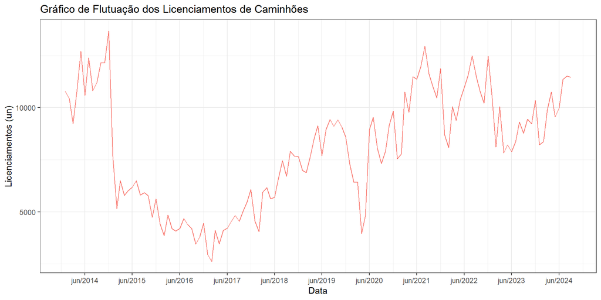

### PIB - Deflacionado

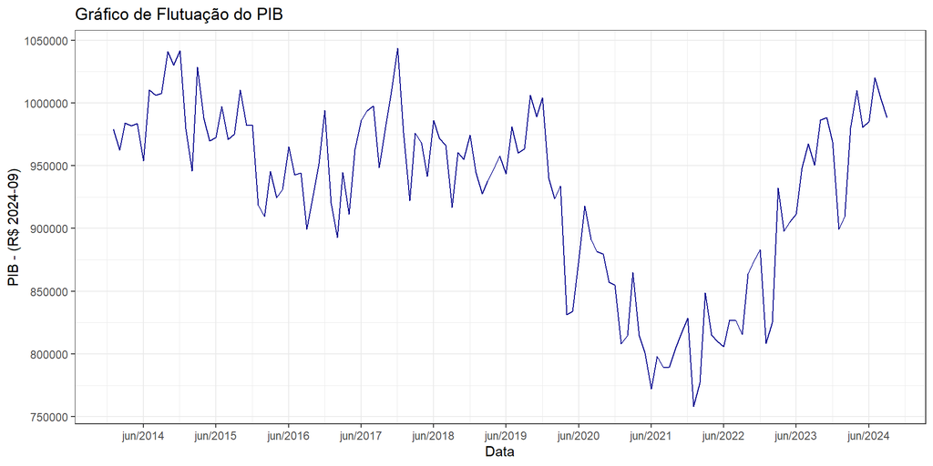

### Câmbio

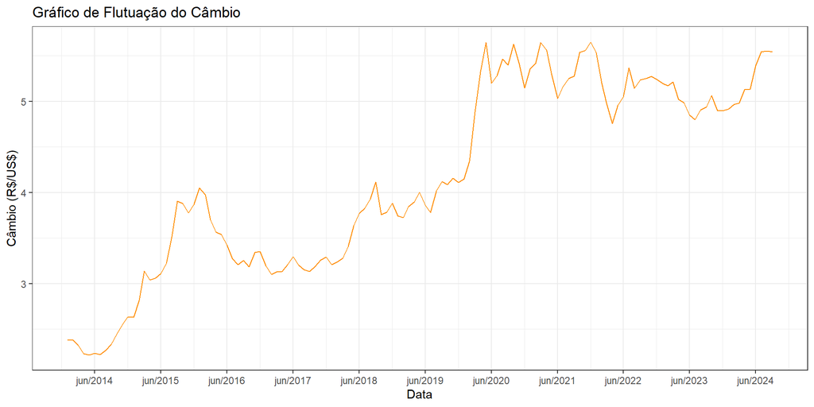

### Selic

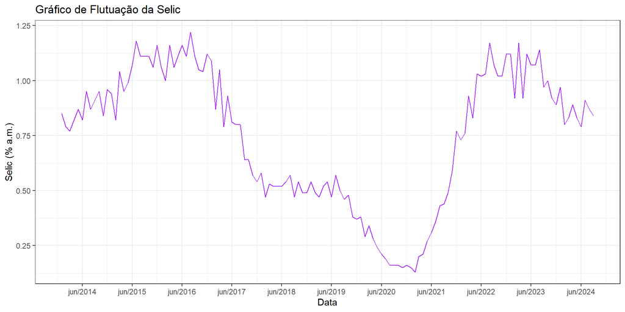

### Produção Industrial

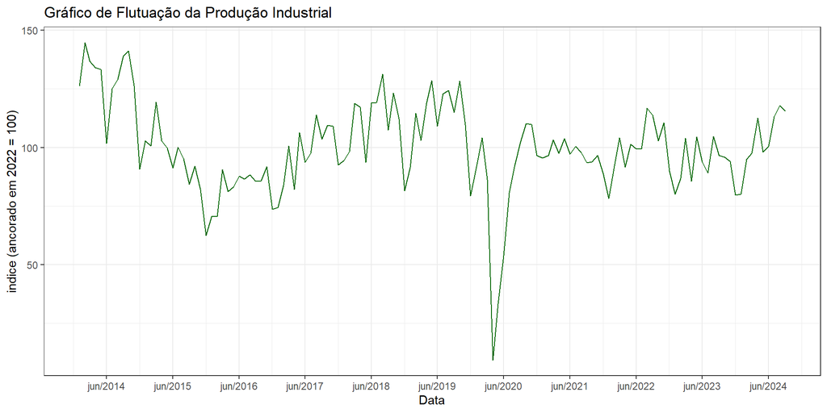

### Inflação - IGP-M

[figure not shown]

# **4. VARIÁVEIS MACRO FUTURAS**

> Para poder realizar as modelagens, a opção seguida neste exercício foi de priorizar a obtenção de variáveis macroeconômicas futuras por meio da obtenção de dados de expectativas de mercado. O Bacen, em seu site: Sistema Gerenciador de Séries Temporais (SGS) (https://www3.bcb.gov.br/sgspub/) apresenta compilados de expectativas de vários agentes de mercado e compila essas informações na sessão no Sistema de Expectativas de Mercado (https://www3.bcb.gov.br/expectativas2/#/consultas).

> Como o exercício pretende prever o licenciamento de caminhões através de informações macroeconômicas, a forma ideal seria confiar nas previsões dos entes de mercado que, em tese, deveriam ser mais acuradas do que uma previsão endógena em um modelo linear estatístico como o que será aplicado asseguir.

## **4.1 Capturando as séries**

> **No sistema, os dados que apresentam agregação a nível mensal são apenas os de Inflação (IGP-M) e a taxa de câmbio. A Selic está disponível a nível de 45 em 45 dias (Reuniões do Copom), enquanto as demais estão a nível anual (PIB) ou não possuem mais continuidade de análise (Produção Industrial).**

```r
# 1. Testar estacionaridade (ADF test)
adf.test(base$licen)
```

```
##
##  Augmented Dickey-Fuller Test
##
## data:  base$licen
## Dickey-Fuller = -3.0202, Lag order = 5, p-value = 0.1524
## alternative hypothesis: stationary
```

```r
adf.test (base$pib)
```

```
##
##  Augmented Dickey-Fuller Test
##
## data:  base$pib
## Dickey-Fuller = -1.2193, Lag order = 5, p-value = 0.9004
## alternative hypothesis: stationary
```

```r
adf.test (base$selic)
```

```
##
##  Augmented Dickey-Fuller Test
##
## data:  base$selic
## Dickey-Fuller = -2.0255, Lag order = 5, p-value = 0.5659
## alternative hypothesis: stationary
```

```r
adf.test (base$tx_cambio)
```

```
##
##  Augmented Dickey-Fuller Test
##
## data:  base$tx_cambio
## Dickey-Fuller = -2.3623, Lag order = 5, p-value = 0.4259
## alternative hypothesis: stationary
```

```r
adf.test (base$prod_ind)
```

```
##
##  Augmented Dickey-Fuller Test
##
## data:  base$prod_ind
## Dickey-Fuller = -3.0514, Lag order = 5, p-value = 0.1394
## alternative hypothesis: stationary
```

```r
adf.test (base$infl)
```

```
##
##  Augmented Dickey-Fuller Test
##
## data:  base$infl
## Dickey-Fuller = -2.7763, Lag order = 5, p-value = 0.2538
## alternative hypothesis: stationary
```

```r
# 2. Diferenciar as séries para torná-las estacionárias
data_diff <- data.frame(
  # dLicen          = diff(base$licen),
  dGDP            = diff(base$pib),
  dInflation      = diff(base$infl),
  dIndustrialProd = diff(base$prod_ind),
  dSelic          = diff(base$selic),
  dExchangeRate   = diff(base$tx_cambio)
)

# 3. Selecionar a ordem do VAR (número de defasagens)
VARselect(data_diff, lag.max = 10, type = "const")
```

```
## $selection
## AIC(n)  HQ(n)  SC(n) FPE(n)
##     10      1      1     10
##
## $criteria
##                   1            2            3            4            5
## AIC(n) 1.663922e+01 1.668880e+01 1.664588e+01 1.662928e+01 1.677628e+01
## HQ(n)  1.692523e+01 1.721315e+01 1.740857e+01 1.763032e+01 1.801566e+01
## SC(n)  1.734363e+01 1.798022e+01 1.852431e+01 1.909472e+01 1.982873e+01
## FPE(n) 1.684655e+07 1.774315e+07 1.709471e+07 1.699502e+07 2.003541e+07
##                   6            7            8            9           10
## AIC(n) 1.671575e+01 1.660195e+01 1.646426e+01 1.625395e+01 1.614663e+01
## HQ(n)  1.819348e+01 1.831802e+01 1.841867e+01 1.844671e+01 1.857773e+01
## SC(n)  2.035521e+01 2.082842e+01 2.127774e+01 2.165444e+01 2.213412e+01
## FPE(n) 1.936203e+07 1.793512e+07 1.643914e+07 1.424118e+07 1.394488e+07
```

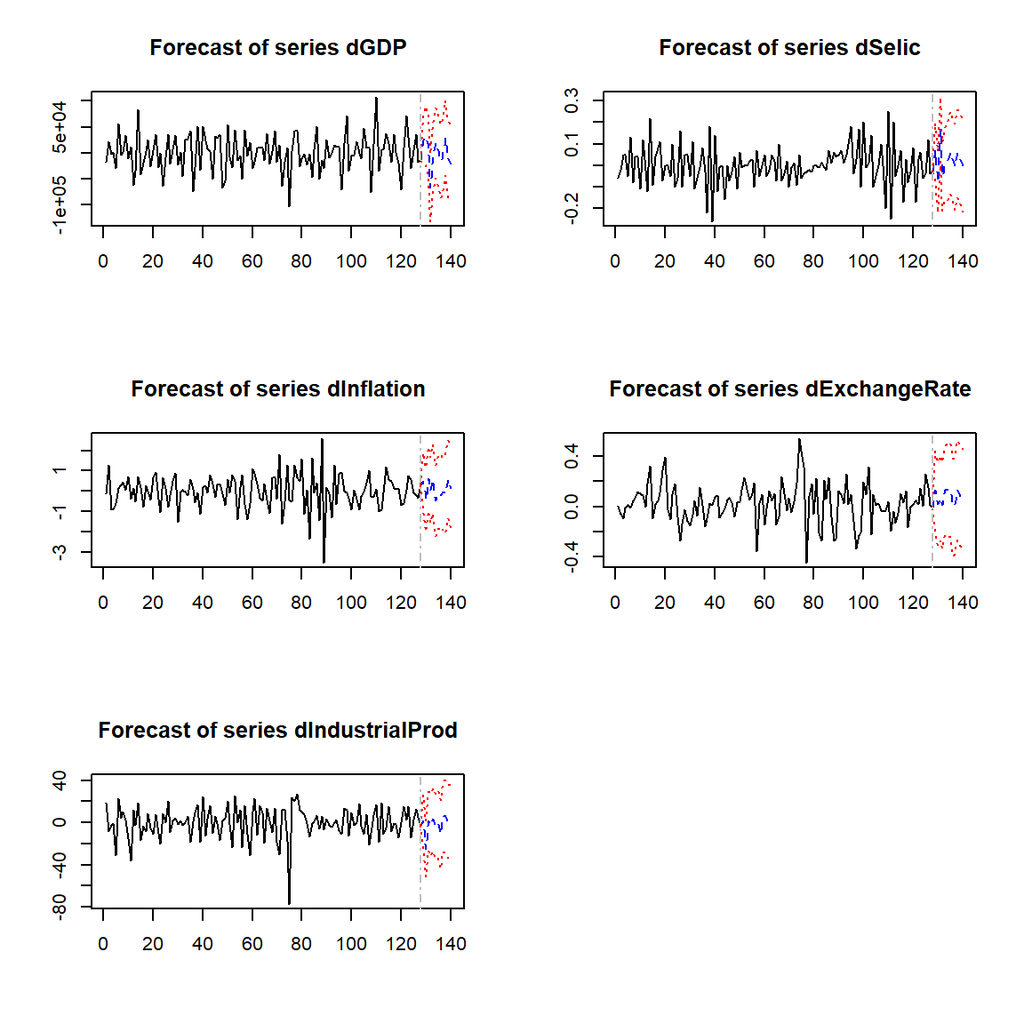

```r
# 4. Estimar o modelo VAR
var_model <- VAR(data_diff, p = 10, type = "const")

previsao_var <- predict(var_model, n.ahead = 12)

# dispondo os dados
# df_predict_lic <- as.data.frame(previsao_var$fcst$dLicen)
df_predict_ind <- as.data.frame(previsao_var$fcst$dIndustrialProd)
df_predict_pib <- as.data.frame(previsao_var$fcst$dGDP)
df_predict_inf <- as.data.frame(previsao_var$fcst$dInflation)
df_predict_cam <- as.data.frame(previsao_var$fcst$dExchangeRate)
df_predict_sel <- as.data.frame(previsao_var$fcst$dSelic)

# criando data frame total e retornando a diferenciacao das series

xreg_future <- data.frame(
  pib = c(cumsum(df_predict_pib$fcst) + base$pib[129]      ),
  ind = c(cumsum(df_predict_ind$fcst) + base$prod_ind[129] ),
  inf = c(cumsum(df_predict_inf$fcst) + base$infl[129]     ),
  cam = c(cumsum(df_predict_cam$fcst) + base$tx_cambio[129]),
  sel = c(cumsum(df_predict_sel$fcst) + base$selic[129]    )
)


plot(previsao_var)
```

```r
# disponibilizando os dados
DT::datatable(df_predict_pib, options = list(pageLength = 12))
```

|  | fcst | lower | upper | CI |
| --- | --- | --- | --- | --- |
| 1 | 23414.9135674395 | -22707.94466911915 | 69537.77180399814 | 46122.85823655865 |
| 2 | 32422.13338918191 | -24654.96914286402 | 89499.23592122784 | 57077.10253204593 |
| 3 | 13290.30500520989 | -46048.81786382706 | 72629.42787424685 | 59339.12286903695 |
| 4 | -66581.7867068046 | -131029.3904742175 | -2134.1829393917 | 64447.6037674129 |
| 5 | -9039.518572691419 | -75000.43670664764 | 56921.3995612648 | 65960.91813395622 |
| 6 | 20066.14545118436 | -47176.7488609334 | 87309.03976330212 | 67242.89431211776 |
| 7 | 5489.922880756102 | -63088.11689430691 | 74067.96265581911 | 68578.039775063 |
| 8 | -15471.78414199078 | -85257.98082997517 | 54314.41254599362 | 69786.1966879844 |
| 9 | -4212.922349656587 | -74769.24453323132 | 66343.39983391816 | 70556.32218357474 |
| 10 | 28986.23166527056 | -43031.11508070827 | 101003.5784112494 | 72017.34674597884 |

[output cut: 2 more lines]

# **4. ANÁLISE ECONOMÉTRICA**

#### **Como discutido anteriormente, a análise econométrica se dará utilizando o ARIMAX ou o SARIMAX. A escolha do modelo dependerá da existência ou não de uma sazonalidade estatisticamente significante presente nos dados históricos de licenciamento.**

> 1. **Tornar a série Estacionária:** Se os dados não forem estacionários, será realizada a diferenciação para remover tendências e sazonalidade, garantindo que os dados tenham média e variância constantes.

> 2 **Selecionar a Ordem e Sazonalidade do modelo SARIMAX:** Parametrizar a função auto.arima e conferir os diferentes tipos de ajuste.
> 3. **Testar a necessidade das variáveis exógenas:** Após ajustar o modelo, será verificada a significância estatística das variáveis macroeconômicas para identificar se a remoção de variáveis menos relevantes melhora o ajuste do modelo.
> 4. **Avaliar o Modelo:** Avaliar o desempenho do modelo usando medidas estatísticas como erro médio quadrático (MSE), Critério de Informação Akaike (AIC) e Critério de Informação Bayesiano (BIC).
> 5. **Fazer Previsões:** Utilizar o modelo SARIMAX ajustado para prever os períodos futuros.

### Separando a Série em treino e teste

```r
serie_licen_total <- ts(base$licen, frequency = 12, start = c(2014, 1))

serie_licen_train <- ts(
  base[base$mes_ano < "2023-09-01",]$licen,
  frequency = 12,
  start = c(2014, 1)
)

serie_licen_test  <- ts(
  base[base$mes_ano >= "2023-09-01",]$licen,
  frequency = 12,
  start = c(2023, 09)
)
```

## **4.1 Testando a hipóteses para esolha do modelo**

> Antes da verificação de Sazonalidade através de testes estatísticos já estruturados, para que eles operem da forma mais adequada, a série deve estar livre da presença de tendência. Portanto, primeiramente será testada a presença de tendência e, caso exista, será removida.

### Presença de Tendência

#### **Teste KPSS**

```r
# Aplicando o teste KPSS com a hipótese nula de estacionariedade em torno de uma tendência
library(tseries)
kpss.test(serie_licen_train, null = "Trend")
```

```
##
##  KPSS Test for Trend Stationarity
##
## data:  serie_licen_train
## KPSS Trend = 0.33114, Truncation lag parameter = 4, p-value = 0.01
```

#### **Teste Phillips - Perron

```r
# Aplicar o teste PP
pp.test(serie_licen_train)
```

```
##
##  Phillips-Perron Unit Root Test
##
## data:  serie_licen_train
## Dickey-Fuller Z(alpha) = -13.049, Truncation lag parameter = 4, p-value
## = 0.3608
## alternative hypothesis: stationary
```

#### Teste ADF - Generalizado

```r
library(urca)

# Aplicar o teste DF-GLS
dfgls_test <- ur.df(serie_licen_train, type = "trend", selectlags = "AIC")
summary(dfgls_test)
```

```
##
## ###############################################
## # Augmented Dickey-Fuller Test Unit Root Test #
## ###############################################
##
## Test regression trend
##
##
## Call:
## lm(formula = z.diff ~ z.lag.1 + 1 + tt + z.diff.lag)
##
## Residuals:
##     Min      1Q  Median      3Q     Max
## -4786.6  -649.3   -90.7   797.7  3724.8
##
## Coefficients:
##              Estimate Std. Error t value Pr(>|t|)
## (Intercept) 648.31541  374.65933   1.730  0.08636 .
## z.lag.1      -0.13263    0.04768  -2.781  0.00637 **
## tt            6.28850    3.91256   1.607  0.11086
## z.diff.lag   -0.09592    0.09365  -1.024  0.30796
## ---
## Signif. codes:  0 '***' 0.001 '**' 0.01 '*' 0.05 '.' 0.1 ' ' 1
##
## Residual standard error: 1274 on 110 degrees of freedom
## Multiple R-squared:  0.09028,    Adjusted R-squared:  0.06547
## F-statistic: 3.639 on 3 and 110 DF,  p-value: 0.01507
##
##
## Value of test-statistic is: -2.7813 2.7078 4.0557
##
## Critical values for test statistics:
##       1pct  5pct 10pct
## tau3 -3.99 -3.43 -3.13
## phi2  6.22  4.75  4.07
## phi3  8.43  6.49  5.47
```

> Isso sugere que, de acordo com o teste DF-GLS, há evidências de que a série `serie_licen` não é estacionária.

### Diferenciando a série

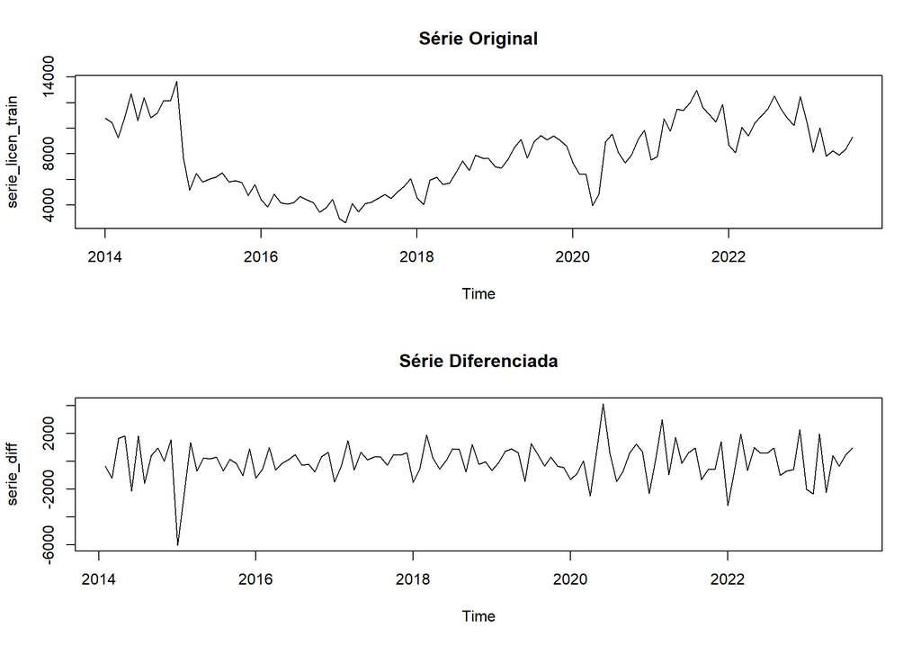

```r
# Diferenciar a série 'serie_licen'
serie_diff <- diff(serie_licen_train)

# Dividir a área do gráfico em duas linhas e uma coluna
par(mfrow = c(2, 1))

# Plotar a série original
plot(serie_licen_train, main = "Série Original")

# Plotar a série diferenciada
plot(serie_diff, main = "Série Diferenciada")
```

### Presença de Sazonalidade

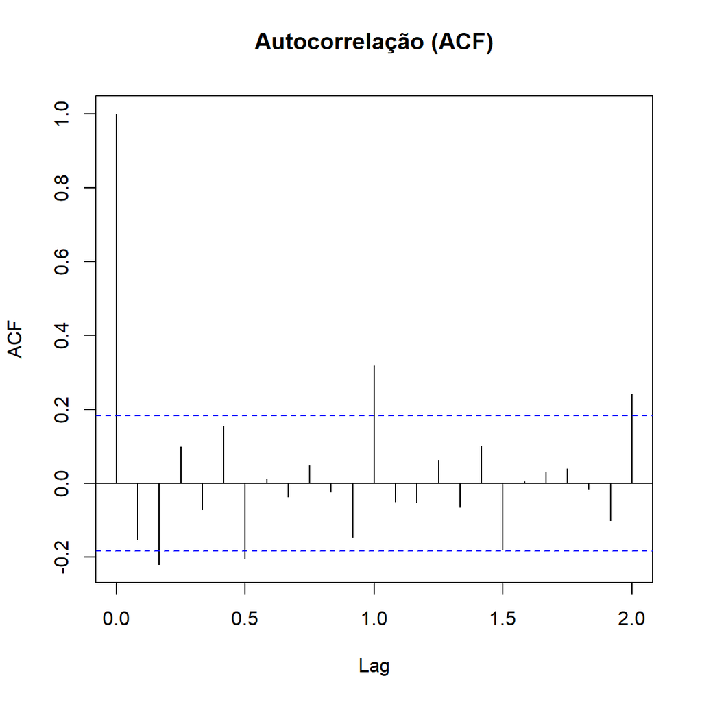

```r
# Plotar a ACF
acf(serie_diff, main = "Autocorrelação (ACF)", lag.max = 24)
```

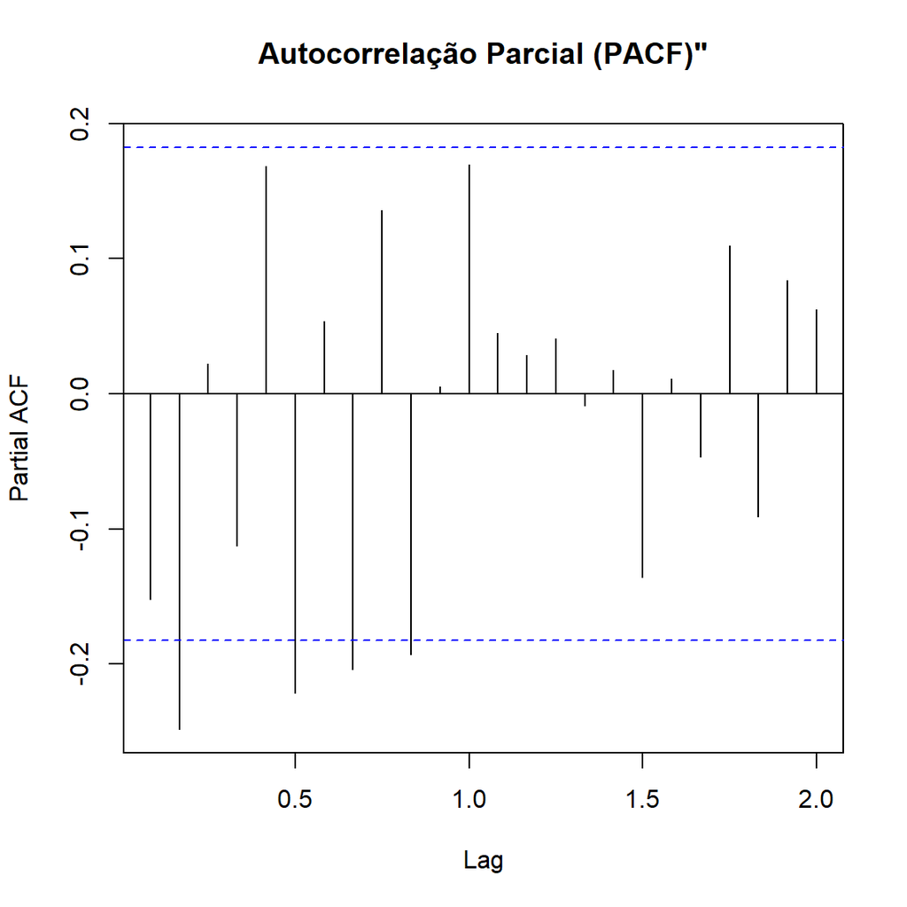

```r
# Plotar a PACF
pacf(serie_diff, main = 'Autocorrelação Parcial (PACF)"',lag.max = 24)
```

> ao observer o ACF e o PACF, Claramente existe um componente sazonal anual onde é negativamente relacionado com o $t-6$ e positivamente com o $t-12$. Essa é uma clara indicação de sazonalidade que será devidamente testada a seguir.

### Teste de Kruskal-Wallis

> O teste de Kruskal-Wallis verifica se há diferenças significativas entre as medianas de dois ou mais grupos. No seu caso, ele compara as medianas dos valores da sua série temporal (serie_diff) em cada mês do ano. Para isso, o teste ordena todos os valores da série, independentemente do mês, e atribui um “posto” (posição na ordem) para cada um. Então, ele calcula a soma dos postos para cada mês e verifica se a diferença entre essas somas é grande o suficiente para ser considerada estatisticamente significativa, ou seja, improvável de acontecer por acaso.

```r
# fator que represente os períodos (meses, no caso de frequência 12)
meses <- factor(cycle(serie_diff))

# teste de Kruskal-Wallis
kruskal.test(serie_diff ~ meses)
```

```
##
##  Kruskal-Wallis rank sum test
##
## data:  serie_diff by meses
## Kruskal-Wallis chi-squared = 52.951, df = 11, p-value = 1.832e-07
```

> O teste de Friedman verifica se existe sazonalidade em uma série temporal comparando as medianas dos valores em diferentes períodos sazonais (meses, trimestres, etc.). O teste organiza os dados em uma tabela onde cada linha representa um ano e cada coluna um mês e então classifica os valores de cada ano, do menor para o maior, e calcula a média dos ranks de cada mês em todos os anos. Se houver sazonalidade, ou seja, se os valores tendem a ser maiores em certos meses consistentemente ao longo dos anos, as médias dos ranks desses meses serão significativamente diferentes das médias dos ranks dos outros meses

```r
library(seastests)
fried(serie_licen_train, freq = 12, diff = T, residuals = F, autoarima = T)
```

```
## Test used:  Friedman rank
##
## Test statistic:  56.71
## P-value:  3.763482e-08
```

```r
library(forecast)
```

> O valor-p indica a probabilidade de observar uma diferença entre as medianas dos grupos tão grande quanto a observada em seus dados, caso não houvesse realmente diferença entre os grupos (hipótese nula de que não há sazonalidade).

> Neste caso, o valor indica uma forte diferença entre as medianas dos grupos indicando a existência de sazonalidade.

## **4.2 Aplicando o SARIMAX**

> A classe de modelos ARIMA assume entre outras premissas básicas que a série temporal estudada é estacionária, livre de tendência e sazonalidade. A estacionariedade de uma série pode ser verificada a partir do teste de Dickey Fuller, equanto que o efeito de sazonalidade pode ser visto através da visualização da decomposição entre tendência, sazonalidade e resíduo, ou identificada pelo próprio gráfico. Enquanto o efeito de estacionariedade pode ser removido através da diferenciação o efeito da sazonalidade precisa ser contabilizado caso a série assim se comporte.

> Neste sentido podemos definir sazonalidade como sendo a tendência de um processo em se repetir dentro de um determinado período.

> A partir deste contexto é fácil perceber que a hipótese de ausência de sazonalidade em uma série temporal pode representar uma limitação significativa para a modelagem com modelos ARIMA. Essa motivação levou à criação de uma nova classe de modelos denominados em inglês por *Seasonal Autoregressive Integrated Moving Average* (SARIMA). A motivação para esses modelos corresponde exatamente à tentativa de capturar os padrões nos dados que se repetem em intervalos periódicos, tais como dias, meses e anos.

> O modelo SARIMA inclui tanto componentes sazonais como componentes não sazonais. Desta forma, compreendendo em profundidade a modelagem SARIMA temos uma ferramenta poderosa de forecast que leva em conta elementos sazonais.

### **Explicação do Modelo**

> De uma forma geral, um modelo SARIMA pode ser representado da seguinte forma:

$$SARIMA(p,d,q)(P,D,Q)_m$$

> onde:
> - $p$ é a ordem da componente autoregressiva (AR) entre a série e os seus lags, e P tem o mesmo significado para a componente sazonal.
> - $d$ é o grau de diferenciação necessário para obter estacionariedade na série, D tem o mesmo significado para a componente sazonal.
> - $q$ é a ordem da média móvel (MA), que modela a relação entre a série e os resíduos, e Q tem o mesmo significado para a componente sazonal.
> - $m$ representa o período observado.

> Vale notar que $m$, é um parâmetro que depende do intervalo de tempo dos dados. Se temos dados medidos ao longo de 1 ano e observamos uma sazonalidade com período de 12 meses, o valor de $m$ será $m=12$.

> Neste ponto, vale a pena entendermos a equação que é ajustada em um modelo SARIMA:

$$W_t^{'}=\underbrace{\Delta^d Y_t}_{\text {série após d diferenças }}$$

> o que define o parâmetro d. No caso da série se tornar estacionária após uma diferenciação (d=1), teríamos que $W_t^{'}=Y_t-Y_{t-1}$. No entanto, em uma série com sazonalidade eventualmente também precisamos diferenciar a série na componente sazonal e assim definir o parâmetro D, de tal forma que $W_t=Y_t-Y_{t-1m}$, onde $m$ é o período observado. Deste modo a equação para $W_t$ seria:

$$W_t=c +(
\underbrace{\phi_1 W_{t-1}+\ldots+\phi_p W_{t-p}}_{\mathrm{p} \text { -
termos autorregressivos }}+
\underbrace{\theta_1 e_{t-1}+\ldots+\theta_q e_{t-q}}_{\mathrm{q} \text
{ - termos de Médias moveis }})+
(\underbrace{\Phi_1 W_{t-1m}+\ldots+\Phi_p W_{t-Pm}}_{\mathrm{P} \text {
- termos sazonais autorregressivos }}+
\underbrace{\Theta_1 e_{t-1m}+\ldots+\Theta_q e_{t-Qm}}_{\mathrm{Q}
\text { - termos sazonais de Médias moveis }})+
e_t,$$

> em que $\phi_1, \ldots, \phi_p, \theta_1, \ldots, \theta_q,\Phi_1, \ldots, \Phi_p, \Theta_1, \ldots, \Theta_q$ são valores a serem estimados e $e_t$ é o ruído branco. A título de exemplo, um modelo SARIMA(2,0,3)$\times$(2,0,1,12), ajustaria a seguinte função:

$$W_t=
c+
(\underbrace{\phi_1 W_{t-1}+\phi_2 W_{t-2}}_{\mathrm{p} \text { - termos
autorregressivos }}+
\underbrace{\theta_1 e_{t-1}+\theta_2 e_{t-2}+\theta_3
e_{t-3}}_{\mathrm{q} \text { - termos de Médias moveis }})+
(\underbrace{\Phi_1 W_{t-(1\times12)}+\Phi_2
W_{t-(2\times12)}}_{\mathrm{P} \text { - termos sazonais
autorregressivos }}+
\underbrace{\Theta_1 e_{t-(1\times12)}}_{\mathrm{Q} \text { - termos
sazonais de Médias moveis }})+
e_t,$$

### Identificando o Modelo

> Neste tipo de caso procedemos com uma sequência de análises necessárias para a aplicação do modelo SARIMA através das seguintes etapas:
> - Verificada a estacionariedade: foram utilizados varios testes de Dickey Fuller aumentado, o de Phillips-Perron e o KPSS.
> - Verificada sazonalidade: Utilizando os testes de Friedman e Kruskal-Wallis.
> - Definir os parâmetros (p,d,q)(P,D,Q,m): será usada a função auto.arima para varrer o espaço de parâmetros.
> - Fazer a previsão de valores: o modelo será ajustado com o melhor conjunto de parâmetros encontrados no passo anterior e na sequência será feita a predição para o intervalo de tempo desejado.

$$W_t^{'}=Y_t-Y_{t-1}$$

> mas não a diferença:

$$W_t=Y_t-Y_{t-1×12}$$

> Vale também observar os plots da ACF e PACF deste conjunto de dados, de modo a evidenciar as correlações entre os diferentes lags.

> Para identificar o modelo de uma forma mais pratica, será utilizada a função auto.arima com parâmetro `seasonal = TRUE`. Dessa forma, os parâmetros (p, d, q) para o componente ARIMA e (P, D, Q, s) para a sazonalidade serão selecionados automaticamente através de um processo de iteração dos possíveis termos onde a escolha do melhor conjunto de especificações é dado com base na minimização da estatística AIC.

> o comando **auto.arima** da linguagem **R**. Esse comando irá nos ajudar a varrer o espaço de parâmetros e encontrar os valores ótimos de (p,d,q)$\times$(P,D,Q)$_m$. De um modo geral, o comando tenta proceder a uma espécie de **grid search** experimentando vários valores de **p** e **q** (assim como das componentes sazonais **P** e **Q**) diferentes, definindo o melhor modelo a partir do menor valor do AIC (também é possível escolher a partir do BIC ou outro critério).

```r
modelo_total <- auto.arima(
  serie_licen_train,
  xreg = as.matrix(base %>% filter(mes_ano< '2023-09-01') %>% dplyr::select(-licen,-mes_ano)),
  seasonal = TRUE,
  trace = TRUE
)
```

```
##
##  Regression with ARIMA(2,0,2)(1,0,1)[12] errors : 1945.21
##  Regression with ARIMA(0,0,0)            errors : 2113.235
##  Regression with ARIMA(1,0,0)(1,0,0)[12] errors : 1936.996
##  Regression with ARIMA(0,0,1)(0,0,1)[12] errors : 2026.191
##  Regression with ARIMA(0,0,0)            errors : 2111.209
##  Regression with ARIMA(1,0,0)            errors : 1937.735
##  Regression with ARIMA(1,0,0)(2,0,0)[12] errors : 1939.386
##  Regression with ARIMA(1,0,0)(1,0,1)[12] errors : 1939.389
##  Regression with ARIMA(1,0,0)(0,0,1)[12] errors : 1937.114
##  Regression with ARIMA(1,0,0)(2,0,1)[12] errors : 1941.342
##  Regression with ARIMA(0,0,0)(1,0,0)[12] errors : 2084.229
##  Regression with ARIMA(2,0,0)(1,0,0)[12] errors : 1938.546
##  Regression with ARIMA(1,0,1)(1,0,0)[12] errors : 1938.398
##  Regression with ARIMA(0,0,1)(1,0,0)[12] errors : 2016.985
##  Regression with ARIMA(2,0,1)(1,0,0)[12] errors : Inf
##  Regression with ARIMA(1,0,0)(1,0,0)[12] errors : Inf
##
##  Best model: Regression with ARIMA(1,0,0)(1,0,0)[12] errors
```

> Como parâmetros para a execução da função **auto_arima** foram passadas as opções `seasonal=True`, de modo que ele considere a possibilidade de uma série com sazonalidade. O parâmetro Trace=True permite que ao longo da execução possamos visualizar o conjunto de parâmetros testados.

### **Analisando o Modelo**

```r
summary(modelo_total)
```

```
## Series: serie_licen_train
## Regression with ARIMA(1,0,0)(1,0,0)[12] errors
##
## Coefficients:
##          ar1    sar1   intercept     pib     selic  tx_cambio  prod_ind
##       0.9575  0.2204  -11101.276  0.0197  2845.936  -402.8961    2.9306
## s.e.  0.0246  0.1248    4146.457  0.0036  1264.788   542.2995    7.2302
##           infl
##       -63.2689
## s.e.  102.8796
##
## sigma^2 = 920798:  log likelihood = -958.65
## AIC=1935.3   AICc=1937   BIC=1960.08
##
## Training set error measures:
##                     ME     RMSE      MAE        MPE     MAPE      MASE
## Training set -15.63165 925.9023 655.9238 -0.9016587 9.078122 0.3036157
##                    ACF1
## Training set 0.08917316
```

### Interpretando Coeficientes

> **O coeficiente AR(1) de 0.9575 indica uma forte autocorrelação positiva, sugerindo que o valor da série em um período anterior tem um impacto positivo e significativo no valor atual. O coeficiente SAR(1) de 0.2204 indica uma autocorrelação sazonal positiva, mas menor, sugerindo que o valor da série no mesmo período do ano anterior também influencia positivamente o valor atual.**

> **As variáveis independentes PIB, Selic, taxa de câmbio e inflação apresentam os seguintes coeficientes: 0.0197, 2845.936, -402.8961 e -63.2689, respectivamente. Esses coeficientes indicam o impacto de cada variável na série, sendo positivo para PIB e Selic e negativo para taxa de câmbio e inflação. No entanto, apenas os coeficientes do PIB e da Selic são estatisticamente significativos, dado seus baixos erro padrão.**

### Comparando outros modelos

> **A necessidade de variáveis exógenas para o forecast pode ser questionada a medida em que o modelo indique a baixa necessidade dela nos calculos. Contudo, apesar de inicialmente parecer uma boa ideia retira-las a medida em que o AIC e o BIC possa melhorar, existe o problema da retirada de variáveis necessárias para o modelo o que pode mudar o comportamento do erro tranformando-o em um erro correlacionado com as previsões, tornando o resultado viesado e mal especificado.**

> **Por conta disso, será considerada a retirada de apenas uma variável exógena e, será analisada sua relevância teórica para a análise.**

```r
modelo_1 <- auto.arima(
  serie_licen_train,
  xreg = as.matrix(base %>% filter(mes_ano< '2023-09-01') %>%  dplyr::select(-licen, -mes_ano, -prod_ind)),
  seasonal = TRUE
)
modelo_2 <- auto.arima(
  serie_licen_train,
  xreg = as.matrix(base %>% filter(mes_ano< '2023-09-01') %>% dplyr::select(-licen, -mes_ano, -tx_cambio)),
  seasonal = TRUE
)
modelo_3 <- auto.arima(
  serie_licen_train,
  xreg = as.matrix(base %>% filter(mes_ano< '2023-09-01') %>% dplyr::select(-licen, -mes_ano, -infl)),
  seasonal = TRUE
)
```

```r
summary(modelo_1)
```

```
## Series: serie_licen_train
## Regression with ARIMA(0,1,0) errors
##
## Coefficients:
##          pib     selic  tx_cambio       infl
##       0.0197  3472.257  -485.3861  -111.9106
## s.e.  0.0030  1129.804   546.9711   106.9139
##
## sigma^2 = 936174:  log likelihood = -951.74
## AIC=1913.48   AICc=1914.03   BIC=1927.21
##
## Training set error measures:
##                     ME     RMSE      MAE        MPE     MAPE      MASE
## Training set -9.432697 946.4786 678.2031 -0.1712182 9.392024 0.3139284
##                    ACF1
## Training set 0.07715026
```

```r
cat('\n \n \n',paste0(rep('=', 60),collapse = ''), '\n \n \n')
summary(modelo_2)
```

```
## Series: serie_licen_train
## Regression with ARIMA(0,1,0)(0,1,1)[12] errors
##
## Coefficients:
##          sma1     pib    selic  prod_ind      infl
##       -0.7239  0.0028  2730.70   28.1295   40.9728
## s.e.   0.1360  0.0055  1322.32    9.0152  103.5598
##
## sigma^2 = 965028:  log likelihood = -857.69
## AIC=1727.39   AICc=1728.26   BIC=1743.2
##
## Training set error measures:
##                    ME   RMSE      MAE      MPE     MAPE      MASE        ACF1
## Training set 46.41469 902.93 626.1776 1.403796 10.04636 0.2898467 0.004160233
```

```r
cat('\n \n \n',paste0(rep('=', 60),collapse = ''), '\n \n \n')
summary(modelo_3)
```

```
## Series: serie_licen_train
## Regression with ARIMA(1,0,0)(1,0,0)[12] errors
##
## Coefficients:
##          ar1    sar1   intercept     pib     selic  tx_cambio  prod_ind
##       0.9563  0.2360  -10597.423  0.0192  2855.296  -424.2703    3.3042
## s.e.  0.0250  0.1214    4083.359  0.0035  1270.246   540.7232    7.2962
##
## sigma^2 = 914741:  log likelihood = -958.84
## AIC=1933.68   AICc=1935.03   BIC=1955.71
##
## Training set error measures:
##                     ME     RMSE      MAE        MPE     MAPE      MASE
## Training set -15.65807 927.1146 659.9029 -0.9103724 9.158598 0.3054576
##                    ACF1
## Training set 0.09210616
```

> **Como é possivel ver nas regressões abaixo, a medida em que vai se removendo as variáveis com não significantes do modelo, os indicadores de AIC e BIC vão diminuindo, contúdo, as medidas de erro dos modelos se alteram em um formato não tão linear demonstrando que, a depender da variável retirada o modelo pode ser pior.**

> **Além disso, a retirada de algumas variáveis altera o modelo selecionado pelo auto arima. Para escolher a melhor opção de retirada, será considarado qual o modelo que menos altera o original e entrega os melhores parâmetros de erro e AIC e BIC sem tornar o erro correlacionado.**

### Analisando os residuos

> **O teste Ljung-Box é usado para verificar se os resíduos de um modelo de série temporal são autocorrelacionados, ou seja, ele verifica se existe algum padrão nos resíduos que o modelo não conseguiu capturar.**

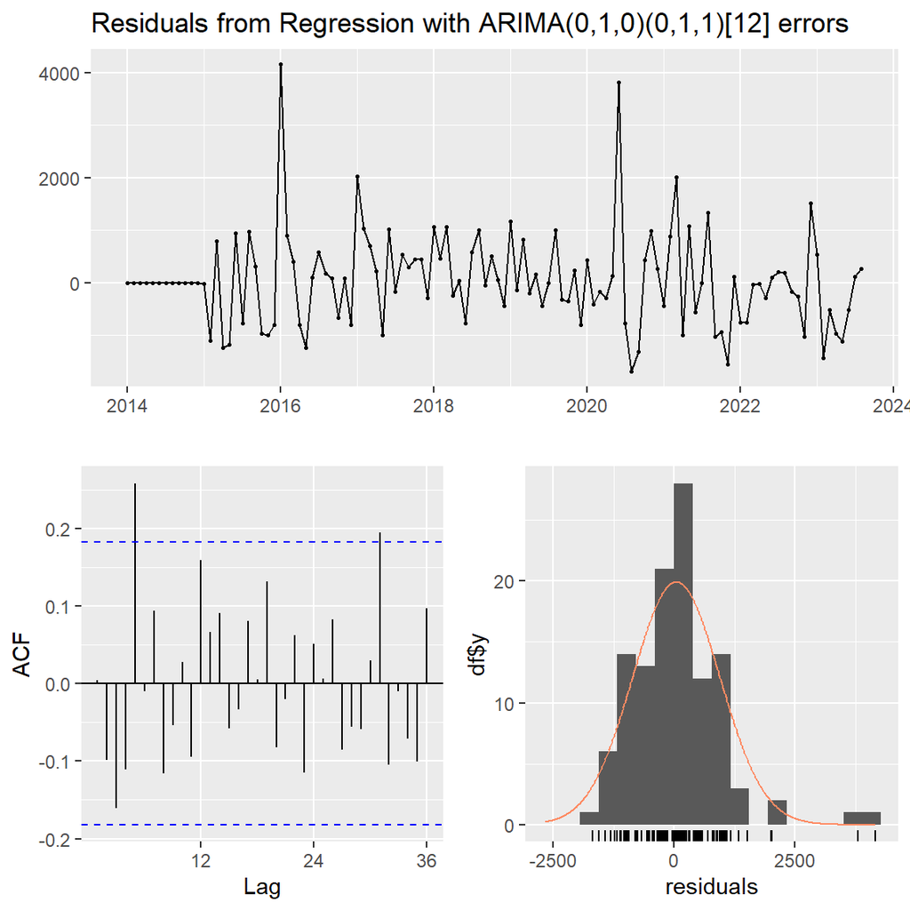

```
##
##  Ljung-Box test
##
## data:  Residuals from Regression with ARIMA(0,1,0)(0,1,1)[12] errors
## Q* = 30.961, df = 22, p-value = 0.09692
##
## Model df: 1.   Total lags used: 23
```

```r
checkresiduals(modelo_2)
```

> **A hipótese nula do teste Ljung-Box é que os resíduos não são autocorrelacionados. Um valor-p alto indica que não há evidências suficientes para rejeitar a hipótese nula, o que indica o modelo ARIMA(0,1,0)(0,1,1)[12] como sendo um bom agente em capturar a autocorrelação nos dados.**

### Enxergando o encaixe do Modelo nos dados

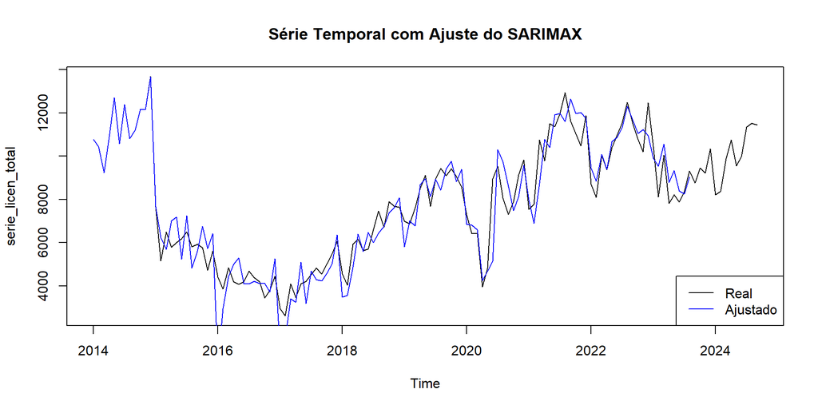

```r
plot(serie_licen_total, main = "Série Temporal com Ajuste do SARIMAX")
lines(fitted(modelo_2), col = "blue")  # Adiciona os valores ajustados
legend("bottomright", legend = c("Real", "Ajustado"), col = c("black", "blue"), lty = 1)
```

### Testando o modelo nos dados de teste

```r
previsao <- forecast(
  modelo_2,
  xreg = as.matrix(base %>% filter(mes_ano>="2023-09-01") %>% dplyr::select(-licen, -mes_ano, -tx_cambio)),
  # h = 12
  )
resultados_previsao <- summary(previsao)

resultados_previsao$model
```

```
## Series: serie_licen_train
## Regression with ARIMA(0,1,0)(0,1,1)[12] errors
##
## Coefficients:
##          sma1     pib    selic  prod_ind      infl
##       -0.7239  0.0028  2730.70   28.1295   40.9728
## s.e.   0.1360  0.0055  1322.32    9.0152  103.5598
##
## sigma^2 = 965028:  log likelihood = -857.69
## AIC=1727.39   AICc=1728.26   BIC=1743.2
```

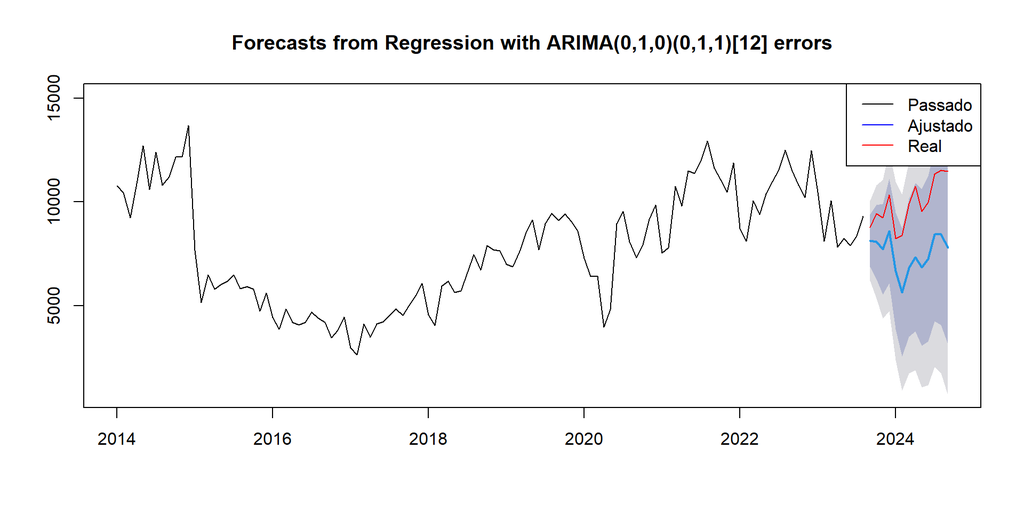

```r
serie_dados_finais <- window(serie_licen_total, start = c(2023, 9))
plot(previsao)
lines(serie_dados_finais, col = "red")  # Adiciona os valores ajustados
legend("topright", legend = c("Passado", "Ajustado", 'Real'), col = c("black", "blue", 'red'), lty = 1)
```

## **4.2 Previsão** $t+12$

> **Agora, será feito o mesmo processo para identificar o melhor modelo para os dados totais e aplicar a previsão.**

### Fitando modelo para o grupo dos “totais”

```r
modelo_final <- auto.arima(
  serie_licen_total,
  xreg = as.matrix(base %>% dplyr::select(-licen,-mes_ano)),
  seasonal = TRUE
)

summary(modelo_final)
```

```
## Series: serie_licen_total
## Regression with ARIMA(1,0,0)(1,0,0)[12] errors
##
## Coefficients:
##          ar1    sar1   intercept     pib     selic  tx_cambio  prod_ind
##       0.9543  0.2412  -11849.278  0.0207  2313.385  -215.8352    4.2921
## s.e.  0.0252  0.1111    3884.243  0.0033  1152.716   504.1198    6.9943
##           infl
##       -69.0663
## s.e.   96.5725
##
## sigma^2 = 854953:  log likelihood = -1061.62
## AIC=2141.24   AICc=2142.76   BIC=2166.98
##
## Training set error measures:
##                     ME     RMSE     MAE        MPE     MAPE      MASE
## Training set -9.644094 895.5068 634.017 -0.9369948 8.577018 0.2981846
##                    ACF1
## Training set 0.07875973
```

```r
write.csv2(base, 'G:/Meu Drive/Cases/case_MT2-Data/Dados/dados_finais/base_sarimax.csv')
```

### **Aplicando modelos sem variáveis**

```r
summary(modelo_1)
```

[output not shown]

```r
cat('\n \n \n',paste0(rep('=', 60),collapse = ''), '\n \n \n')
summary(modelo_2)
```

[output not shown]

```r
cat('\n \n \n',paste0(rep('=', 60),collapse = ''), '\n \n \n')
summary(modelo_3)
```

```
## Series: serie_licen_total
## Regression with ARIMA(1,0,0)(1,0,0)[12] errors
##
## Coefficients:
##          ar1    sar1   intercept     pib     selic  tx_cambio  prod_ind
##       0.9529  0.2546  -11324.389  0.0201  2343.606  -233.9246    4.7751
## s.e.  0.0256  0.1096    3825.206  0.0033  1155.576   503.4283    7.0541
##
## sigma^2 = 850894:  log likelihood = -1061.88
## AIC=2139.76   AICc=2140.96   BIC=2162.64
##
## Training set error measures:
##                     ME     RMSE      MAE        MPE     MAPE      MASE
## Training set -9.788005 897.0628 638.7281 -0.9501121 8.662046 0.3004003
##                    ACF1
## Training set 0.08302647
```

#### **Neste caso, o modelo ideal a ser escolhido será o inicial com todas as variávies, por conta que seu AIC e BIC não são extremamente distantes dos demais.**

### Aplicando as previsões do modelo

```r
previsao <- forecast(
  modelo_final,
  xreg = as.matrix(xreg_future %>% dplyr::select(pib, sel, cam, ind, inf)),
  )
resultados_previsao <- summary(previsao)

resultados_previsao$model
```

```
## Series: serie_licen_total
## Regression with ARIMA(1,0,0)(1,0,0)[12] errors
##
## Coefficients:
##          ar1    sar1   intercept     pib     selic  tx_cambio  prod_ind
##       0.9543  0.2412  -11849.278  0.0207  2313.385  -215.8352    4.2921
## s.e.  0.0252  0.1111    3884.243  0.0033  1152.716   504.1198    6.9943
##           infl
##       -69.0663
## s.e.   96.5725
##
## sigma^2 = 854953:  log likelihood = -1061.62
## AIC=2141.24   AICc=2142.76   BIC=2166.98
```

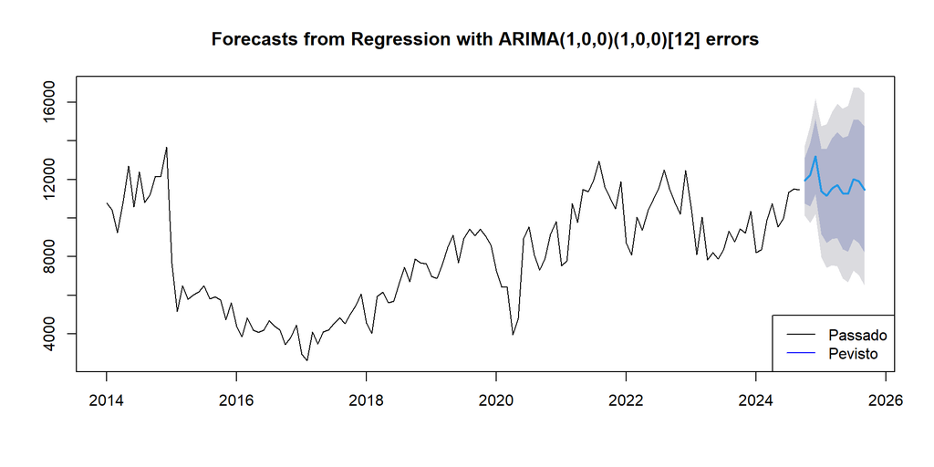

```r
# Visualizar os resultados
plot(previsao)
legend("bottomright", legend = c("Passado", "Pevisto"), col = c("black", "blue"), lty = 1)
```

### Analisando os residuos

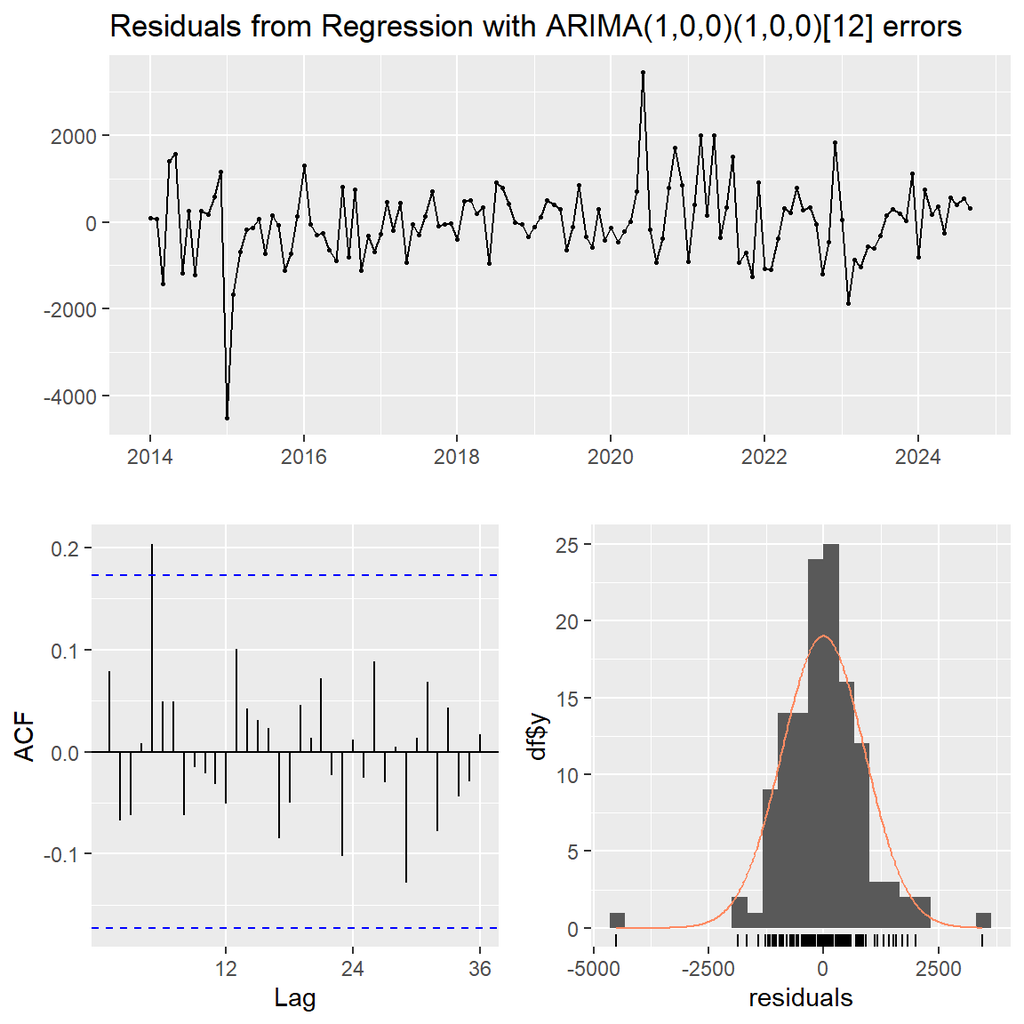

```
##
##  Ljung-Box test
##
## data:  Residuals from Regression with ARIMA(1,0,0)(1,0,0)[12] errors
## Q* = 15.774, df = 22, p-value = 0.8269
##
## Model df: 2.   Total lags used: 24
```

```r
checkresiduals(modelo_final)
```

# **5. ANÁLISE MACHINE LEARNING**

> **Toda a ideia de aplicar um modelo de Machine Learning nesses dados é tentar capturar os padrões complexos não lineares que as variáveis possam apresentar na tentativa de melhorar o Forecast. Contúdo, boa parte desses algorítimos, por conta de sua estrutura algorítimica, exige uma grande quantidade de dados para que ele funcione adequadamente.**

> **As Redes Neurais (LSTM/RNN) não foram consideradas pois geralmente necessitam de centenas ou milhares de observações para generalizar bem, o que torna a aplicação arriscada no seu cenário.**

> **Obeservando os algoritmios de Random Forest / Gradient Boosting, ambos os métodos tendem a performar melhor com conjuntos de dados maiores. Com apenas 120 observações, há risco de overfitting (o modelo ajusta-se muito bem aos dados de treino, mas generaliza mal nos dados de teste).**

> **O Gradient Boosting (XGBoost, LightGBM, CatBoost) Geralmente supera o Random Forest em termos de acurácia, especialmente em datasets menores, porque otimiza o ajuste incrementalmente (boosting) permitindo um ajuste mais fino de hiperparâmetros, o que pode ser vantajoso para melhorar a performance no seu conjunto de dados, além de ser robusto a ruídos e overfitting em pequenos datasets, especialmente se bem calibrado.**

## **5.1 Aplicação do Modelo** $t+12$

> **O modelo se dará seguindo os seguintes passos:**
> - **1. Engenharia de Recursos:** Criação de novas features a partir das existentes como dummies de tempo para a captura de padrões sazonais, além de lags da variável a ser predita.
> - **2. Treinamento do Modelo:** Definição dos Hiperparâmetros tais como o número de iterações de boosting; a taxa de aprendizado, a profundidade máxima da árvore, subamostragem de linhas e a subamostragem de colunas.
> - **3. Ajustando os Hiperparâmetros:** Aplicar os calculos para fazer a melhor seleção de parametros possível.
> - **4. Avaliação do Modelo e Previsão:** Realizar as previsões com o modelo treinado usando os dados de teste conferindo as métricas de avaliação relevantes MSE, MAE, R-quadrado.

### **1. Criando novas Features**

> **A engenharia de recursos é essencial para capturar padrões complexos nas séries temporais que podem influenciar as previsões. A criação de variáveis defasadas (lags) da variável-alvo ajuda o modelo a aprender dependências temporais, como tendências e ciclos. Adicionalmente, variáveis que representam o tempo (como trimestres ou semestres) permitem que o modelo capture efeitos sazonais, caso existam. Esses novos recursos fornecem informações adicionais e enriquecem o conjunto de dados, permitindo que o modelo identifique relações mais significativas.**

```r
# Instalar pacotes necessários
library(xgboost)
library(dplyr)
library(caret)
# Função para criar lags (defasagens)
create_lags <- function(data, target, lags = 1:3) {
  for (lag in lags) {
    data[[paste0(target, "_lag", lag)]] <- dplyr::lag(data[[target]], lag)
  }
  return(data)
}

# Preparar os dados
base <- base %>%
  # Ordenar os dados por data
  arrange(mes_ano) %>%

  # estabelecendo variáveis sazonais
  mutate(
    anual     = cut(mes_ano, breaks = "12 month", labels = FALSE),
    semestre  = cut(mes_ano, breaks = "6 month", labels = FALSE),
    trimestre = cut(mes_ano, breaks = "3 month", labels = FALSE),
    bimestre  = cut(mes_ano, breaks = "2 month", labels = FALSE)
  ) %>%

  # Criar variáveis defasadas
  create_lags("licen", lags = 1:3) %>%
  # Remover NAs gerados pelas defasagens
  na.omit()


# disponibilizando os dados
DT::datatable(base, options = list(pageLength = 12))
```

|  | mes_ano | licen | pib | selic | tx_cambio | prod_ind | infl | anual | semestre | trimestre | bimestre | licen_lag1 | licen_lag2 | licen_lag3 |
| --- | --- | --- | --- | --- | --- | --- | --- | --- | --- | --- | --- | --- | --- | --- |
| 1 | 2014-04-01 | 10888 | 981746.975344854 | 0.82 | 2.231725 | 133.98463 | 0.78 | 1 | 1 | 2 | 2 | 9241 | 10437 | 10778 |
| 2 | 2014-05-01 | 12710 | 983665.5109801656 | 0.87 | 2.220280952 | 133.25308 | -0.13 | 1 | 1 | 2 | 3 | 10888 | 9241 | 10437 |
| 3 | 2014-06-01 | 10585 | 954084.6499171157 | 0.82 | 2.23486 | 101.82421 | -0.74 | 1 | 1 | 2 | 3 | 12710 | 10888 | 9241 |
| 4 | 2014-07-01 | 12388 | 1010358.544392876 | 0.95 | 2.224021739 | 125.01451 | -0.61 | 1 | 2 | 3 | 4 | 10585 | 12710 | 10888 |
| 5 | 2014-08-01 | 10807 | 1006100.988667118 | 0.87 | 2.26742381 | 129.05795 | -0.27 | 1 | 2 | 3 | 4 | 12388 | 10585 | 12710 |
| 6 | 2014-09-01 | 11210 | 1007691.81356314 | 0.91 | 2.332254545 | 139.05077 | 0.2 | 1 | 2 | 3 | 5 | 10807 | 12388 | 10585 |
| 7 | 2014-10-01 | 12172 | 1041102.722514477 | 0.95 | 2.447643478 | 141.25427 | 0.28 | 1 | 2 | 4 | 5 | 11210 | 10807 | 12388 |
| 8 | 2014-11-01 | 12153 | 1030155.673944395 | 0.84 | 2.54823 | 126.38273 | 0.98 | 1 | 2 | 4 | 6 | 12172 | 11210 | 10807 |
| 9 | 2014-12-01 | 13686 | 1041798.46230677 | 0.96 | 2.638736364 | 90.67936 | 0.62 | 1 | 2 | 4 | 6 | 12153 | 12172 | 11210 |
| 10 | 2015-01-01 | 7661 | 979549.5362998461 | 0.94 | 2.633619048 | 102.79266 | 0.76 | 2 | 3 | 5 | 7 | 13686 | 12153 | 12172 |

[output cut: 116 more lines]

### **2. Treinamento do Modelo**

> **O treinamento do modelo envolve a configuração de hiperparâmetros, que são críticos para controlar a capacidade e o desempenho do XGBoost. Por exemplo, o número de iterações de boosting e a taxa de aprendizado determinam como o modelo ajusta seus parâmetros ao longo do treinamento, equilibrando entre precisão e risco de overfitting. A profundidade máxima da árvore limita a complexidade dos padrões que o modelo pode aprender, enquanto a subamostragem de linhas e colunas adiciona aleatoriedade para evitar sobreajuste e melhorar a generalização. Esses ajustes garantem que o modelo seja robusto e eficiente ao capturar os padrões relevantes.**

```r
# Separar dados de treino e teste
train_size <- floor(0.9 * nrow(base))  # 90% para treino
train_data <- base[1:train_size, ]
test_data <- base[(train_size + 1):nrow(base), ]

# Matriz de treino (X e y)
X_train <- as.matrix(train_data %>% dplyr::select(-mes_ano, -licen))  # Variáveis preditoras
y_train <- train_data$licen  # Variável-alvo

# Matriz de teste (X e y)
X_test <- as.matrix(test_data %>% dplyr::select(-mes_ano, -licen))
y_test <- test_data$licen

# Treinar o modelo XGBoost
xgb_model <- xgboost(
  data = X_train,
  label = y_train,
  objective = "reg:squarederror", # Regressão
  nrounds = 500,                  # Número de iterações (boosting rounds)
  eta = 0.1,                      # Taxa de aprendizado
  max_depth = 3,                  # Profundidade máxima da árvore
  subsample = 0.8,                # Subamostragem de linhas
  colsample_bytree = 0.8,         # Subamostragem de colunas
  verbose = 0                     # Suprime a saída de log
)
```

### **3. Ajustando os Hiperparâmetros**

> **O ajuste dos hiperparâmetros é necessário para encontrar a configuração que maximize o desempenho do modelo. Essa etapa utiliza técnicas como validação cruzada para testar combinações de hiperparâmetros e selecionar aquelas que melhor equilibram viés e variância. Ajustes precisos, como a escolha da profundidade das árvores, taxa de aprendizado e subamostragem, podem melhorar significativamente a capacidade preditiva do modelo sem introduzir overfitting. Essa etapa é crucial para otimizar os resultados e garantir previsões confiáveis.**

```r
# Grid de hiperparâmetros corrigido
grid <- expand.grid(
  nrounds = c(100, 300),          # Número de árvores
  max_depth = c(2, 3),              # Profundidade máxima
  eta = c(0.01, 0.1),             # Taxa de aprendizado
  gamma = c(0, 1),                     # Regularização para divisões (split)
  colsample_bytree = c(0.8, 1),   # Subamostragem de colunas
  min_child_weight = c(1, 3),       # Tamanho mínimo de um nó
  subsample = c(0.8, 1)                # Subamostragem de linhas
)

# Configuração da validação cruzada com janela deslizante
control <- trainControl(
  method = "timeslice",
  initialWindow = 80,  # Janela inicial de treino
  horizon = 10,        # Horizonte para validação
  fixedWindow = TRUE   # Janela fixa
)

# Ajuste do modelo com validação cruzada
xgb_tuned <- train(
  licen ~ pib + selic + tx_cambio + prod_ind + infl + anual + semestre + trimestre + licen_lag1 + licen_lag2 + licen_lag3,
  data = train_data,
  method = "xgbTree",
  trControl = control,
  tuneGrid = grid
)
# salvando objeto com melhores parâmetros
write.csv(
  xgb_tuned$resample,
  'G:/Meu Drive/Cases/case_MT2-Data/Dados/dados_intermediarios/resample.csv',
  row.names = FALSE
)
write.csv(
  xgb_tuned$results,
  'G:/Meu Drive/Cases/case_MT2-Data/Dados/dados_intermediarios/results.csv',
  row.names = FALSE
)
write.csv(
  xgb_tuned$bestTune,
  'G:/Meu Drive/Cases/case_MT2-Data/Dados/dados_intermediarios/bestTune.csv',
  row.names = FALSE
)

# Exibir os melhores hiperparâmetros encontrados
DT::datatable(xgb_tuned$bestTune, options = list(pageLength = 7))
```

[output not shown]

### **3. Avaliação do Modelo:**

> **Após a realização do encontro dos melhores hiperparâmetros, iremos reaplicar o modelo e verificar seu desempenho.**

> **A avaliação do modelo é fundamental para medir o quão bem ele se adapta aos dados de teste, que representam cenários futuros não vistos durante o treinamento. Métricas como o MSE (erro médio quadrático) e MAE (erro absoluto médio) quantificam a precisão das previsões, enquanto o R-quadrado avalia a proporção de variabilidade explicada pelo modelo. Avaliar o desempenho com dados de teste permite identificar se o modelo está generalizando adequadamente ou se está superajustado aos dados de treino.**

```r
# Calcular métricas de avaliação
DT::datatable(

  results %>% filter(
    nrounds           == bestTune$nrounds &
      max_depth         == bestTune$max_depth &
      gamma             == bestTune$gamma &
      colsample_bytree  == bestTune$colsample_bytree &
      min_child_weight  == bestTune$min_child_weight &
      subsample         == bestTune$subsample &
      eta               == bestTune$eta
  ) %>%
    dplyr::select(MAE, RMSESD, RsquaredSD, MAESD)

  , options = list(pageLength = 3)
)
```

|  | MAE | RMSESD | RsquaredSD | MAESD |
| --- | --- | --- | --- | --- |
| 1 | 1462.48274274554 | 801.264350248276 | 0.18216071725131 | 801.442022202772 |

> **MAESD (Desvio Padrão do Erro Absoluto Médio): 801.44. Essa métrica representa a variabilidade do MAE entre as folds e seu alto valor de 801.44 indica que a precisão do modelo, em termos de erro absoluto, varia consideravelmente entre as folds.**

### Reaplicando o modelo com os melhores parametros

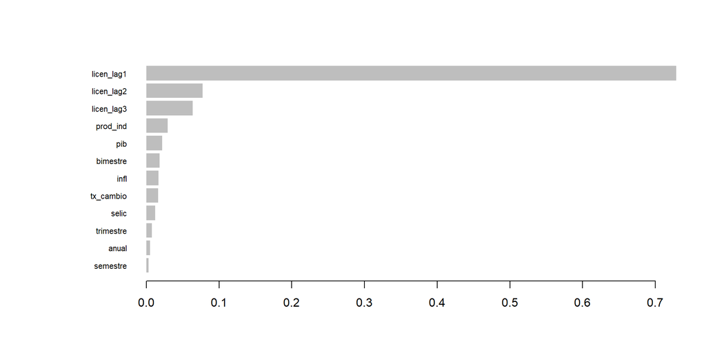

```r
# Treinar o modelo XGBoost
xgb_model <- xgboost(
  data = X_train,
  label = y_train,
  objective = "reg:squarederror", # Regressão
  nrounds = 100,                  # Número de iterações (boosting rounds)
  eta = 0.1,                      # Taxa de aprendizado
  max_depth = 3,                  # Profundidade máxima da árvore
  subsample = 0.8,                  # Subamostragem de linhas
  colsample_bytree = 0.8,         # Subamostragem de colunas
  verbose = 0                     # Suprime a saída de log
)

# Fazer previsões
predictions <- predict(xgb_model, X_test)

# Importância das variáveis
importance <- xgb.importance(feature_names = colnames(X_train), model = xgb_model)

# Plotar a importância das variáveis
xgb.plot.importance(importance_matrix = importance)
```

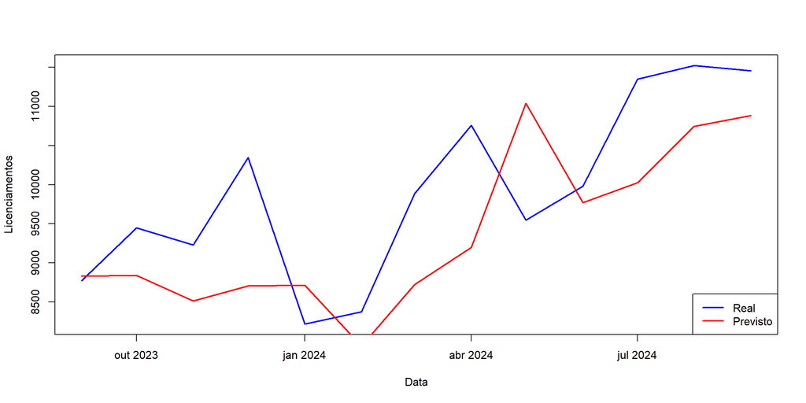

```r
# Plotar os valores reais vs. previstos
plot(test_data$mes_ano, y_test, type = "l", col = "blue", lwd = 2, ylab = "Licenciamentos", xlab = "Data")
lines(test_data$mes_ano, predictions, col = "red", lwd = 2)
legend("bottomright", legend = c("Real", "Previsto"), col = c("blue", "red"), lty = 1, lwd = 2)
```

### Aplicando nos dados totais e conferindo

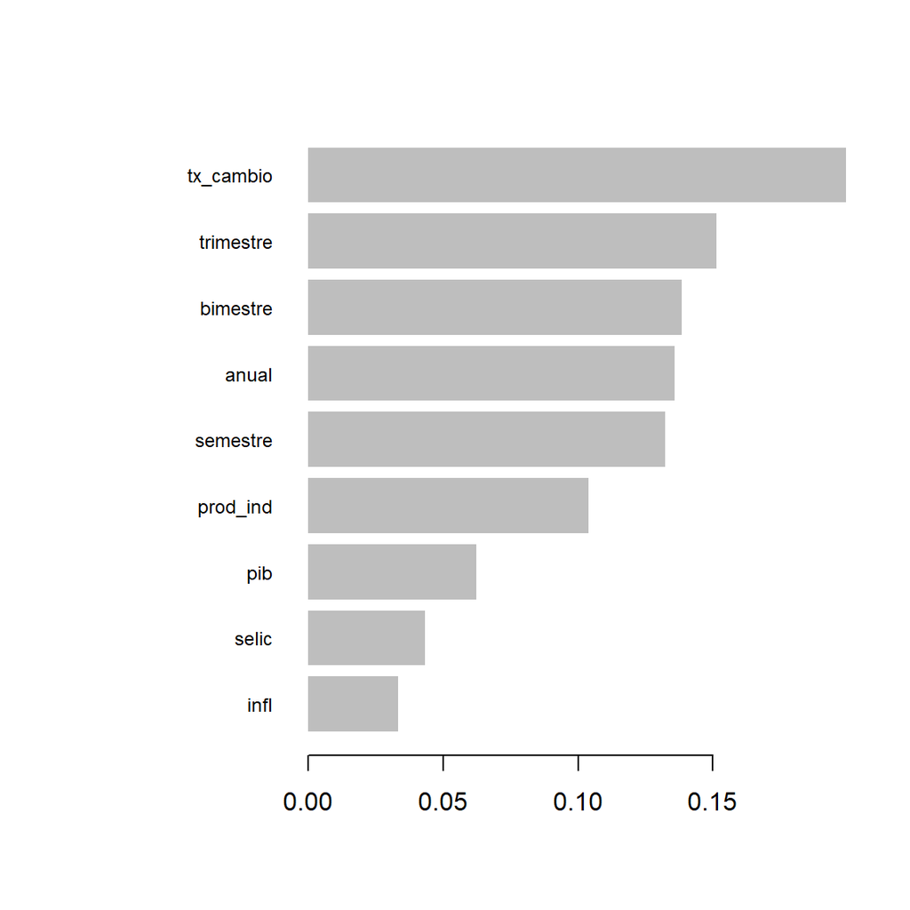

```r
# Matriz de treino (X e y)
X_train <- as.matrix(base %>% dplyr::select(-mes_ano, -licen, -licen_lag1, -licen_lag2, -licen_lag3))  # Variáveis preditoras

y_train <- base$licen  # Variável-alvo

# Treinar o modelo XGBoost
xgb_model <- xgboost(
  data = X_train,
  label = y_train,
  objective = "reg:squarederror", # Regressão
  nrounds = 100,                  # Número de iterações (boosting rounds)
  eta = 0.1,                      # Taxa de aprendizado
  max_depth = 3,                  # Profundidade máxima da árvore
  subsample = 0.8,                # Subamostragem de linhas
  colsample_bytree = 0.8,         # Subamostragem de colunas
  verbose = 0                     # Suprime a saída de log
)


# Importância das variáveis
importance <- xgb.importance(feature_names = colnames(X_train), model = xgb_model)

# Plotar a importância das variáveis
xgb.plot.importance(importance_matrix = importance)
```

### Conferindo o grafico dos resultados

```r
# Funções para calcular as métricas
calc_metrics <- function(y_true, y_pred) {
  mae <- mean(abs(y_true - y_pred))  # Mean Absolute Error
  rmse <- sqrt(mean((y_true - y_pred)^2))  # Root Mean Squared Error
  mape <- mean(abs((y_true - y_pred) / y_true)) * 100  # Mean Absolute Percentage Error

  return(list(MAE = mae, RMSE = rmse, MAPE = mape))
}

fut_data_xgb <- xreg_future %>%
  rename(
    "selic"     = 'sel',
    "tx_cambio" = 'cam',
    "prod_ind"  = 'ind',
    "infl"      = 'inf'
  ) %>%
  mutate(
    bimestre  = c(65,rep(c(66,67,68,69,70), each=2),71),
    trimestre = c(rep(43,3),rep(44,3),rep(45,3),rep(46,3)),
    semestre =  c(22,22,22,rep(23,6),rep(24,3)),
    anual    =  c(11,11,11,rep(12,9))
  ) %>%
  dplyr::select("pib","selic","tx_cambio", "prod_ind","infl","anual","semestre","trimestre","bimestre" )

# Previsões do modelo
y_pred <- predict(xgb_model, newdata = as.matrix(fut_data_xgb))

meses_futuros <- c(paste0('2024-',10:12,"-01"), paste0('2025-0',1:9,'-01'))
```

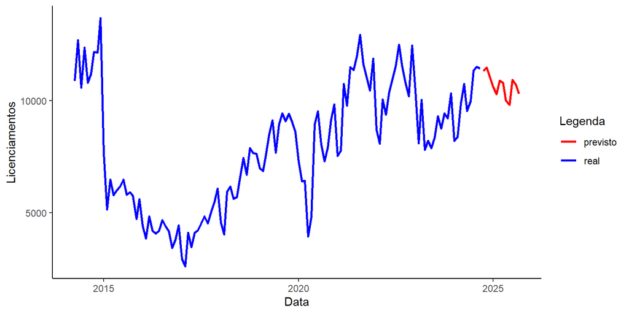

```r
# Plotar os valores reais vs. previstos
# Criar um dataframe com os dados para o gráfico
df_grafico <- data.frame(
  mes_ano = c(base$mes_ano,meses_futuros),
  valores = c(base$licen, y_pred),
  tipo_dado = c( rep('real',length(base$mes_ano)), rep('previsto',length(meses_futuros)) )
)

# Criar o gráfico com ggplot2
# Criar o gráfico com ggplot2
ggplot(df_grafico, aes(x = mes_ano, y = valores, color = tipo_dado)) +
  geom_line(lwd = 1) +
  labs(x = "Data", y = "Licenciamentos", color = "Legenda") +
  scale_color_manual(values = c("real" = "blue", "previsto" = "red")) +
  theme_classic()
```